# UNSUPERVISED LEARNING - CLUSTERING ANALYSIS

********

## Identify Customer Segments

This project aims to apply **unsupervised learning techniques** to **identify segments of the population that form the core customer base for a mail-order sales company in Germany** based on 2 dataset: the demographics subset of Germany population, and the company's customer datset. These segments can then be used to direct marketing campaigns towards audiences that will have the highest expected rate of returns. The data represents a real-life data science task.

# Table of Content

Step 0: Load the data

Step 1: Preprocessing

- Step 1.1: Assess Missing Data
- Step 1.2: Select and Re-Encode Features
- Step 1.3: Create a Cleaning Function

Step 2: Feature Transformation

- Step 2.1: Impute and Apply Feature Scaling
- Step 2.2: Apply Dimension Reduction
- Step 2.3: Interpret Principle Component

Step 3: Clustering

- Step 3.1: Apply Clustering to Population Data
- Step 3.2: Apply Clustering to Customer Data
- Step 3.3: Compare Customer Data to Demographics Data

```python
# import libraries here; add more as necessary
import numpy as np
import pandas as pd
import matplotlib.pyplot as plt
import seaborn as sns
import ast
from sklearn.preprocessing import OneHotEncoder
import copy
import time

#packages for cleansing and clustering
from sklearn.cluster import KMeans
from sklearn.preprocessing import StandardScaler
from sklearn.preprocessing import Imputer
from sklearn.metrics import silhouette_samples, silhouette_score
# magic word for producing visualizations in notebook
%matplotlib inline

from mpl_toolkits.mplot3d import Axes3D
```

### Step 0: Load the Data

```python
# Load in the general demographics data.
azdias = pd.read_csv('Udacity_AZDIAS_Subset.csv',delimiter = ';' )

# Load in the feature summary file.
feat_info = pd.read_csv('AZDIAS_Feature_Summary.csv',error_bad_lines=False, delimiter = ';')
```

```python
feat_info.groupby(['missing_or_unknown']).agg({'attribute':'count'})
```

| missing_or_unknown | attribute |
| --- | --- |
| [-1,0,9] | 1 |
| [-1,0] | 16 |
| [-1,9] | 17 |
| [-1,XX] | 1 |
| [-1,X] | 1 |
| [-1] | 26 |
| [0] | 12 |
| [XX] | 1 |
| [] | 10 |

## Step 1: Preprocessing

### Step 1.1: Assess Missing Data

#### Step 1.1.1: Convert Missing Value Codes to NaNs

```python
def clean_missing_code(feat_df):
    missing_code = feat_df['missing_or_unknown'].unique()
    missing_code.tolist()

    missing_code_list = []
    for i in missing_code:
        try:
            i2 = ast.literal_eval(i)
        except:
            if i =='[-1,X]':
                i2 = [-1,'X']
            elif i == '[XX]':
                i2=['XX']
            else:
                i2=[-1,'XX']
        missing_code_list.append(i2)
    missing_code_list[4] = " "
    return missing_code, missing_code_list

missing_code, missing_code_list = clean_missing_code(feat_info)
```

```python
# Change missing/unknown values to numpy NaNs
def convert_nans(df,feat_df):
    #import clean_missing_code
    missing_code, missing_code_list = clean_missing_code(feat_df)
    for val,key in zip(missing_code,missing_code_list):
        cols = feat_df[feat_df['missing_or_unknown']==val]['attribute'].tolist()
        #print(key, cols)
        df[cols]=df[cols].replace(key,np.nan)
    return df
```

```python
convert_nans(azdias,feat_info).head()
```

|  | AGER_TYP | ALTERSKATEGORIE_GROB | ANREDE_KZ | CJT_GESAMTTYP | FINANZ_MINIMALIST | FINANZ_SPARER | FINANZ_VORSORGER | FINANZ_ANLEGER | FINANZ_UNAUFFAELLIGER | FINANZ_HAUSBAUER | ... | PLZ8_ANTG1 | PLZ8_ANTG2 | PLZ8_ANTG3 | PLZ8_ANTG4 | PLZ8_BAUMAX | PLZ8_HHZ | PLZ8_GBZ | ARBEIT | ORTSGR_KLS9 | RELAT_AB |
| --- | --- | --- | --- | --- | --- | --- | --- | --- | --- | --- | --- | --- | --- | --- | --- | --- | --- | --- | --- | --- | --- |
| 0 | NaN | 2.0 | 1 | 2.0 | 3 | 4 | 3 | 5 | 5 | 3 | ... | NaN | NaN | NaN | NaN | NaN | NaN | NaN | NaN | NaN | NaN |
| 1 | NaN | 1.0 | 2 | 5.0 | 1 | 5 | 2 | 5 | 4 | 5 | ... | 2.0 | 3.0 | 2.0 | 1.0 | 1.0 | 5.0 | 4.0 | 3.0 | 5.0 | 4.0 |
| 2 | NaN | 3.0 | 2 | 3.0 | 1 | 4 | 1 | 2 | 3 | 5 | ... | 3.0 | 3.0 | 1.0 | 0.0 | 1.0 | 4.0 | 4.0 | 3.0 | 5.0 | 2.0 |
| 3 | 2.0 | 4.0 | 2 | 2.0 | 4 | 2 | 5 | 2 | 1 | 2 | ... | 2.0 | 2.0 | 2.0 | 0.0 | 1.0 | 3.0 | 4.0 | 2.0 | 3.0 | 3.0 |
| 4 | NaN | 3.0 | 1 | 5.0 | 4 | 3 | 4 | 1 | 3 | 2 | ... | 2.0 | 4.0 | 2.0 | 1.0 | 2.0 | 3.0 | 3.0 | 4.0 | 6.0 | 5.0 |

5 rows × 85 columns

```python
#test the operations above

i = 6
cols = feat_info[feat_info['missing_or_unknown']==missing_code[i]]['attribute'].tolist()
key = missing_code_list[i]
print(i, key, cols)

print('\n***Values after converting to NaNs***')
for c in cols:
    print(c)
    print(azdias[c].unique())
```

```
6 [-1, 'X'] ['CAMEO_DEUG_2015']

***Values after converting to NaNs***
CAMEO_DEUG_2015
[nan '8' '4' '2' '6' '1' '9' '5' '7' '3']
```

#### Step 1.1.2: Assess Missing Data in Each Column

```python
# Perform an assessment of how much missing data there is in each column of the dataset.

def inspect_missing(df):
    Nulls = df.isna().sum().sum()
    NotNulls = df.notna().sum().sum()
    percent_Nulls = Nulls/(Nulls+NotNulls)
    '''%Nulls value'''
    print('%of Nulls in data', percent_Nulls)
    print('Number of Nulls in data:', Nulls)
    print('Number of data points',Nulls+NotNulls)

    nulls_column_count = df.isna().sum()
    nulls_column = nulls_column_count[nulls_column_count != 0]

    nulls_percent = nulls_column.apply(lambda num:num/len(azdias)*100)
    nulls_df = pd.concat([nulls_column,nulls_percent],axis=1)
    nulls_df.columns = ['#Missing','%Missing']

    #dropped_col = nulls_df[nulls_df['%Missing']>50].index.tolist()
    #print(feat_missing)

    print('\n Top 10 columns with the most Missing values')
    display(nulls_df.sort_values('#Missing',ascending=False).head(10))

    nulls_col_list = nulls_column.index.tolist()
    nonulls_col_list = nulls_column_count[nulls_column_count == 0].index.tolist()
    #print('\n#Columns with Missing Values:',len(nulls_col_list)
     #     ,'\n#Columns with No Missing Values:', len(nonulls_col_list))
    #print('\n Columns with Missing Values\n', nulls_col_list)
    #print('\n Columns with No Missing Values\n', nonulls_col_list)

    #return nulls_df['%Missing'>50].columns
    return nulls_df, nulls_col_list, nonulls_col_list
```

```python
nulls_df, nulls_col_list, nonulls_col_list = inspect_missing(azdias)
```

```
%of Nulls in data 0.11054139407
Number of Nulls in data: 8373929
Number of data points 75753785

 Top 10 columns with the most Missing values
```

|  | #Missing | %Missing |
| --- | --- | --- |
| TITEL_KZ | 889061 | 99.757636 |
| AGER_TYP | 685843 | 76.955435 |
| KK_KUNDENTYP | 584612 | 65.596749 |
| KBA05_BAUMAX | 476524 | 53.468668 |
| GEBURTSJAHR | 392318 | 44.020282 |
| ALTER_HH | 310267 | 34.813699 |
| KKK | 158064 | 17.735668 |
| REGIOTYP | 158064 | 17.735668 |
| W_KEIT_KIND_HH | 147988 | 16.605084 |
| KBA05_ANTG3 | 133324 | 14.959701 |

```python
# Investigate patterns in the amount of missing data in each column.
print('\n Columns with the same number of Null Values:')
unique_na = nulls_df['#Missing'].unique()
col_group = []
for na in unique_na:
    cols = nulls_df[nulls_df['#Missing']==na].index.tolist()
    if len(cols)>1:
        col_group.append(cols)
    else:
        continue

for col in col_group:
    print(col)

print('\nNumber of Column groups with the same #of Nulls Values:', len(col_group))
```

```
 Columns with the same number of Null Values:
['CJT_GESAMTTYP', 'GFK_URLAUBERTYP', 'LP_STATUS_FEIN', 'LP_STATUS_GROB', 'RETOURTYP_BK_S', 'ONLINE_AFFINITAET']
['HEALTH_TYP', 'SHOPPER_TYP', 'VERS_TYP']
['LP_FAMILIE_FEIN', 'LP_FAMILIE_GROB']
['SOHO_KZ', 'ANZ_PERSONEN', 'ANZ_TITEL', 'WOHNDAUER_2008']
['GEBAEUDETYP', 'MIN_GEBAEUDEJAHR', 'OST_WEST_KZ', 'WOHNLAGE']
['CAMEO_DEUG_2015', 'CAMEO_DEU_2015', 'CAMEO_INTL_2015']
['KBA05_ANTG1', 'KBA05_ANTG2', 'KBA05_ANTG3', 'KBA05_ANTG4', 'KBA05_GBZ', 'MOBI_REGIO']
['BALLRAUM', 'EWDICHTE', 'INNENSTADT']
['KKK', 'REGIOTYP']
['PLZ8_ANTG1', 'PLZ8_ANTG2', 'PLZ8_ANTG3', 'PLZ8_ANTG4', 'PLZ8_BAUMAX', 'PLZ8_HHZ', 'PLZ8_GBZ']
['ARBEIT', 'RELAT_AB']

Number of Column groups with the same #of Nulls Values: 11
```

```python
def cast_type(df, feat_df):
    cat_feat = feat_df[feat_df['type']=='categorical']['attribute'].tolist()
    mixed_feat = feat_df[feat_df['type']=='mixed']['attribute'].tolist()
    #cast type of categorical data of azdias2 into category
    df[cat_feat] = df[cat_feat].astype('category')
    df[mixed_feat] = df[mixed_feat].astype('category')
    return df
```

```python
#Drop Columns with the %Nulls>50%.
dropped_cols = ['AGER_TYP', 'TITEL_KZ', 'KK_KUNDENTYP', 'KBA05_BAUMAX','GEBURTSJAHR', 'ALTER_HH']
azdias = cast_type(azdias,feat_info)
azdias2 = azdias.drop(columns = dropped_cols,axis=1).copy()
print(azdias2.shape)
print(azdias.shape)
```

```
(891221, 79)
(891221, 85)
```

#### Summary 1.1.2: Assess Missing Data in Each Column

> - Drop 6 columns with number of Missing Data > 30%: **'TITEL_KZ' (99% missing),'AGER_TYP' (76% missing),'KK_KUNDENTYP' (65% missing),'KBA05_BAUMAX' (53% missing), 'GEBURTSJAHR' (44% missing),'ALTER_HH' (34% missing)**
> - There are 11 Column Groups with the same #of Nulls Values that might be related to each other

#### Step 1.1.3: Assess Missing Data in Each Row

Perform a similar assessment for the rows of the dataset to identify how much data is missing in each row.Divide the data into two subsets: one for data points that are above some threshold for missing values, and a second subset for points below that threshold. In order to know what to do with the outlier rows, we should see if the distribution of data values on columns that are not missing data (or are missing very little data) are similar or different between the two groups. Select at least five of these columns and compare the distribution of values.

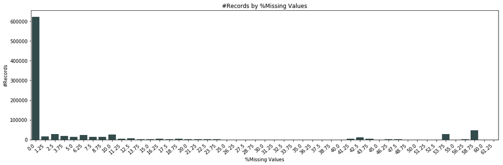

```python
# How much data is missing in each row of the dataset?
def inspect_row(df):
    df['nulls_count']= df.isna().sum(axis=1)
    df['nulls_percent']= df['nulls_count'].apply(lambda num:round(num/azdias2.shape[1]*100,2))

    #azdias2.head(n=5)

    plt.figure(figsize=(15,5))
    ax = sns.countplot(x=df['nulls_percent'], data=df, color="darkslategray")
    ax.set_xticklabels(ax.get_xticklabels(), rotation=40, ha="right",fontsize = 10)
    ax.set_title('#Records by %Missing Values')
    plt.xlabel('%Missing Values')
    plt.ylabel('#Records')
    plt.tight_layout()
    plt.show()

inspect_row(azdias2)
```

```python
# Write code to divide the data into two subsets based on the number of missing
# values in each row.

threshold = 10

def divide_subset(df, threshold):
    df_more = df[df['nulls_percent']>threshold]
    df_less = df[df['nulls_percent']<=threshold]
    print('Subset 1: #Records', df_more.shape[0], '\n*%Records with >{}% Missing values:'.format(threshold),
      round(df_more.shape[0]/df.shape[0]*100,2),'%')
    print('Subset 2: #Records', df_less.shape[0], '\n*%Records with <={}% Missing values:'.format(threshold),
      round(df_less.shape[0]/df.shape[0]*100,2),'%')
    return df_more, df_less

df_more, df_less = divide_subset(azdias2,threshold)
```

```
Subset 1: #Records 119520
*%Records with >10% Missing values: 13.41 %
Subset 2: #Records 771701
*%Records with <=10% Missing values: 86.59 %
```

```
Columns with No Missing Data: ['ANREDE_KZ', 'FINANZ_MINIMALIST', 'FINANZ_SPARER', 'FINANZ_VORSORGER', 'FINANZ_ANLEGER', 'FINANZ_UNAUFFAELLIGER', 'FINANZ_HAUSBAUER', 'FINANZTYP', 'GREEN_AVANTGARDE', 'SEMIO_SOZ', 'SEMIO_FAM', 'SEMIO_REL', 'SEMIO_MAT', 'SEMIO_VERT', 'SEMIO_LUST', 'SEMIO_ERL', 'SEMIO_KU…
```

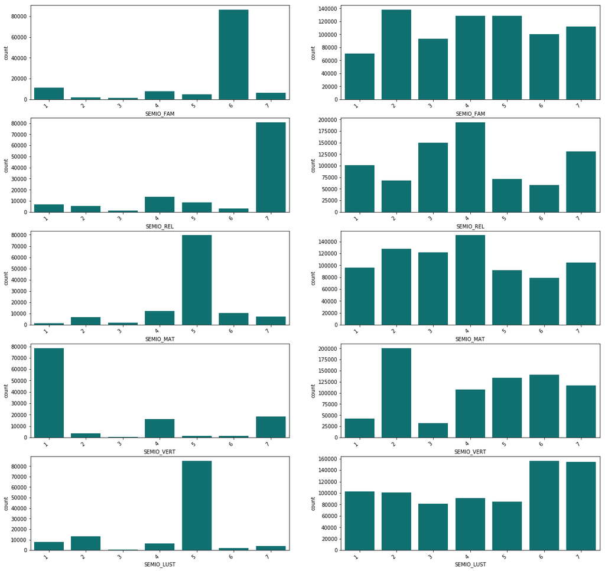

```python
#check whether distribution of data values on columns that are not missing data (or are missing very little data)
#are similar or different between the two groups.
#Select at least five of these columns and compare the distribution of values.
n=10
i=1

print('Columns with No Missing Data:', nonulls_col_list)
c = 9 #define the columns to assess values

plt.figure(figsize=(20,40));
while i <= n:
    if i % 2 !=0:
        c+=1;
        plt.subplot(n,2,i);
        ax = sns.countplot(x=df_more[nonulls_col_list[c]], data=df_more, color="teal");
        ax = ax.set_xticklabels(ax.get_xticklabels(), rotation=40, ha="right",fontsize = 10);

    else:
        plt.subplot(n,2,i);
        ax = sns.countplot(x=df_less[nonulls_col_list[c]], data=df_less,color="teal");
        ax = ax.set_xticklabels(ax.get_xticklabels(), rotation=40, ha="right",fontsize = 10) ;
    i+=1;
```

#### Summary 1.1.3: Assess Missing Data in Each Row

> - The distribution of data based on %mising values shows that about **13% of Records missing mor than 10% of Data**; **86% of Records missing less than 10% of data**. I chose to subset the data based on **10% threshold: 1 subset with 10% or more missing data** and **1 subset with 10% or less missing data**
> - The distribution of **the data subset with lots of missing value** and **the subset with few or no missing values** on columns with no missing data are different

### Step 1.2: Select and Re-Encode Features

- For numeric and interval data, these features can be kept without changes.
- Most of the variables in the dataset are ordinal in nature. While ordinal values may technically be non-linear in spacing, make the simplifying assumption that the ordinal variables can be treated as being interval in nature (that is, kept without any changes).
- Special handling may be necessary for the remaining two variable types: categorical, and 'mixed'.

```python
# How many features are there of each data type?
print('*#featues by Type*')
print(feat_info.groupby('type').agg('attribute').count())

print('\n***Types of Columns dropped***')
dropped_cols = ['AGER_TYP', 'TITEL_KZ', 'KK_KUNDENTYP', 'KBA05_BAUMAX','GEBURTSJAHR', 'ALTER_HH']
display(feat_info[feat_info['attribute'].isin(dropped_cols)]['type'])
```

```
*#featues by Type*
type
categorical    21
interval        1
mixed           7
numeric         7
ordinal        49
Name: attribute, dtype: int64

***Types of Columns dropped***
```

```
0     categorical
11        numeric
40    categorical
43       interval
47    categorical
64          mixed
Name: type, dtype: object
```

```python
#Identify columns by Type

def columns_by_type(feat_info, dropped_cols):
    cat_feat = feat_info[feat_info['type']=='categorical']['attribute'].tolist()
    ord_feat = feat_info[feat_info['type']=='ordinal']['attribute'].tolist()
    num_feat = feat_info[feat_info['type']=='numeric']['attribute'].tolist()
    mixed_feat = feat_info[feat_info['type']=='mixed']['attribute'].tolist()
    int_feat = feat_info[feat_info['type']=='interval']['attribute'].tolist()
    #Remove deleted columns from 'categorical features' and 'mixed features' lists
    cat_feat = [e for e in cat_feat if e not in dropped_cols]
    mixed_feat = [e for e in mixed_feat if e not in dropped_cols]
    num_feat = [e for e in num_feat if e not in dropped_cols]
    int_feat = [e for e in int_feat if e not in dropped_cols]
    return cat_feat, ord_feat, num_feat, mixed_feat, int_feat

cat_feat, ord_feat, num_feat, mixed_feat, int_feat = columns_by_type(feat_info, dropped_cols)

print('Categorical features:\n', cat_feat)
print('\nMixed features:\n', mixed_feat)
print('\nNumeric features:\n', num_feat)
print('\nOrdinal features:\n', ord_feat)
print('\nInterger features:\n', int_feat) #all interger features have been dropped
```

```
Categorical features:
 ['ANREDE_KZ', 'CJT_GESAMTTYP', 'FINANZTYP', 'GFK_URLAUBERTYP', 'GREEN_AVANTGARDE', 'LP_FAMILIE_FEIN', 'LP_FAMILIE_GROB', 'LP_STATUS_FEIN', 'LP_STATUS_GROB', 'NATIONALITAET_KZ', 'SHOPPER_TYP', 'SOHO_KZ', 'VERS_TYP', 'ZABEOTYP', 'GEBAEUDETYP', 'OST_WEST_KZ', 'CAMEO_DEUG_2015', 'CAMEO_DEU_2015']

Mixed features:
 ['LP_LEBENSPHASE_FEIN', 'LP_LEBENSPHASE_GROB', 'PRAEGENDE_JUGENDJAHRE', 'WOHNLAGE', 'CAMEO_INTL_2015', 'PLZ8_BAUMAX']

Numeric features:
 ['ANZ_PERSONEN', 'ANZ_TITEL', 'ANZ_HAUSHALTE_AKTIV', 'ANZ_HH_TITEL', 'MIN_GEBAEUDEJAHR', 'KBA13_ANZAHL_PKW']

Ordinal features:
 ['ALTERSKATEGORIE_GROB', 'FINANZ_MINIMALIST', 'FINANZ_SPARER', 'FINANZ_VORSORGER', 'FINANZ_ANLEGER', 'FINANZ_UNAUFFAELLIGER', 'FINANZ_HAUSBAUER', 'HEALTH_TYP', 'RETOURTYP_BK_S', 'SEMIO_SOZ', 'SEMIO_FAM', 'SEMIO_REL', 'SEMIO_MAT', 'SEMIO_VERT', 'SEMIO_LUST', 'SEMIO_ERL', 'SEMIO_KULT', 'SEMIO_RAT', '…

Interger features:
 []
```

#### Step 1.2.1: Re-Encode Categorical Features

Categorical data need to be encoded as dummy variables. Depending on the number of categories, perform one of the following:

- Keep binary variables with numeric as is.
- Change binary variable that takes on non-numeric values to numeric value (0, 1)
- Encode the values for multiple dummy variables using [OneHotEncoder](http://scikit-learn.org/stable/modules/generated/sklearn.preprocessing.OneHotEncoder.html)

#### Function to engineer category, binary and numeric features

```python
def clean_cat(df,cat_feat):

    bin_feat = []
    multi_feat = []
    for i,cat in enumerate(cat_feat):
        if len(df[cat].unique())==2 or cat == 'VERS_TYP':
            bin_feat.append(cat)
        else:
            multi_feat.append(cat)
        #print('\n',i, "--", cat,"--",df[cat].unique()
         #     , '  \n|%Missing data:', round(df[cat].isna().sum()/df.shape[0],3))


    encoded_feat = copy.deepcopy(multi_feat)
    encoded_feat.remove('CAMEO_DEUG_2015')
    encoded_feat.remove('LP_STATUS_GROB')
    encoded_feat.remove('LP_FAMILIE_GROB')

    #Add 2 mixed features: WOHNLAGE, PLZ8_BAUMAX into the list of encoded features
    encoded_feat.append('WOHNLAGE')
    encoded_feat.append('PLZ8_BAUMAX')


    #add numerical, binary, ordinal features back into the dataframe. Interval feature has been dropped

    df_less_encoded = pd.get_dummies(df[encoded_feat])

    #engineer [OST_WEST_KZ]
    dict_OW = {'O':0,'W':1}
    df_less_encoded['OST_WEST_KZ'] = df['OST_WEST_KZ'].map(dict_OW)
    bin_feat.remove('OST_WEST_KZ')

    df_less_encoded[bin_feat] = df[bin_feat]
    df_less_encoded[num_feat] = df[num_feat]
    df_less_encoded[ord_feat] = df[ord_feat]


    return df_less_encoded

azdias_subset_encoded = clean_cat(df_less,cat_feat)
```

#### Summary 1.2.1: Re-Encode Categorical Features

> - There are **5 Binary** features: *ANREDE_KZ, GREEN_AVANTGARDE, SOHO_KZ, VERS_TYP, OST_WEST_KZ*. Among them, 1 Binary features to change to numeric values: *OST_WEST_KZ*
> - The remaining **13 features** are multi-level. Among these features, a few pairs of features shows similarity in data: *['LP_FAMILIE_FEIN' and 'LP_FAMILIE_GROB'], ['LP_STATUS_FEIN' and 'LP_STATUS_GROB'], ['CAMEO_DEUG_2015' and'CAMEO_DEU_2015']*
> - A quick comparison shows that:
>   > - ['CAMEO_DEUG_2015' AND 'CAMEO_DEU_2015'] are basically similar except **CAMEO_DEU_2015** provides more granular detail
>   > - ['LP_FAMILIE_FEIN' and 'LP_FAMILIE_GROB'] are similar but **'LP_FAMILIE_FEIN'** provides more granular detail
>   > - ['LP_STATUS_FEIN' and 'LP_STATUS_GROB'] are similar but **'LP_STATUS_FEIN'** provides more granular detail
> - I decided to encode all multi-level features except for 3 columns **CAMEO_DEUG_2015**, **LP_STATUS_GROB**, **LP_FAMILIE_GROB**. These 3 columns will be dropped from the analysis

#### Step 1.2.2: Engineer Mixed-Type Features

Based on `Data_Dictionary.md`, there are a handful of features that are marked as "mixed" in the feature summary that require special treatment in order to be included in the analysis. There are two in particular that deserve attention:

- "PRAEGENDE_JUGENDJAHRE" combines information on three dimensions: generation by decade, movement (mainstream vs. avantgarde), and nation (east vs. west) => create two new variables to capture the other two dimensions: an interval-type variable for decade, and a binary variable for movement.
- "CAMEO_INTL_2015" combines information on two axes: wealth and life stage. Break up the two-digit codes by their 'tens'-place and 'ones'-place digits into two new ordinal variables (which, for the purposes of this project, is equivalent to just treating them as their raw numeric values).

#### Function to engineer mixed-type features

```python
def clean_mixed(df_less_encoded, df_less):
    dict_decade = {1.0: 40, 2.0:40, 3.0:50, 4.0:50,5.0:60
                   , 6.0:60,7.0:60,8.0:70,9.0:70,10.0:80
                   ,11.0:80,12.0:80,13.0:80,14.0:90,15.0:90}
    #map Mainstream as 0 and Avantgarde as 1
    dict_movement = {1.0: 0, 2.0:1, 3.0:0, 4.0:1,5.0:0
                   , 6.0:1, 7.0:1, 8.0:0, 9.0:1, 10.0:0
                   ,11.0:1, 12.0:0, 13.0:1, 14.0:0, 15.0:1}

    # Investigate "PRAEGENDE_JUGENDJAHRE" and engineer two new variables.
    df_less_encoded['PRAEGENDE_JUGENDJAHRE_decade']= df_less['PRAEGENDE_JUGENDJAHRE'].map(dict_decade)
    df_less_encoded['PRAEGENDE_JUGENDJAHRE_movement'] = df_less['PRAEGENDE_JUGENDJAHRE'].map(dict_movement)

    # Investigate "CAMEO_INTL_2015" and engineer two new variables.
    df_less.groupby('CAMEO_INTL_2015').size()
    df_less_encoded['CAMEO_INTL_wealth'] = df_less['CAMEO_INTL_2015'].str[0]
    df_less_encoded['CAMEO_INTL_lifestage'] = df_less['CAMEO_INTL_2015'].str[1]

    mixed_feat_encode = ['CAMEO_INTL_wealth','CAMEO_INTL_lifestage']
    encoded_mixed = pd.get_dummies(df_less_encoded[mixed_feat_encode])
    encoded_mixed.columns
    #add the Cameo_INTL, and PRAEGENDE_JUGENDJAHRE_decade after encoded back into df_less_encoded
    df_less_encoded[encoded_mixed.columns]=encoded_mixed[encoded_mixed.columns]

    #drop 2 original Cameo_INTL out of the encoded_dataframe
    df_less_encoded = df_less_encoded.drop(['CAMEO_INTL_wealth','CAMEO_INTL_lifestage'],axis=1)
    display(df_less_encoded.head())
    print(df_less_encoded.shape)
    return df_less_encoded

azdias_subset_encoded = clean_mixed(azdias_subset_encoded,df_less)
```

|  | CJT_GESAMTTYP_1.0 | CJT_GESAMTTYP_2.0 | CJT_GESAMTTYP_3.0 | CJT_GESAMTTYP_4.0 | CJT_GESAMTTYP_5.0 | CJT_GESAMTTYP_6.0 | FINANZTYP_1 | FINANZTYP_2 | FINANZTYP_3 | FINANZTYP_4 | ... | CAMEO_INTL_wealth_1 | CAMEO_INTL_wealth_2 | CAMEO_INTL_wealth_3 | CAMEO_INTL_wealth_4 | CAMEO_INTL_wealth_5 | CAMEO_INTL_lifestage_1 | CAMEO_INTL_lifestage_2 | CAMEO_INTL_lifestage_3 | CAMEO_INTL_lifestage_4 | CAMEO_INTL_lifestage_5 |
| --- | --- | --- | --- | --- | --- | --- | --- | --- | --- | --- | --- | --- | --- | --- | --- | --- | --- | --- | --- | --- | --- |
| 1 | 0 | 0 | 0 | 0 | 1 | 0 | 1 | 0 | 0 | 0 | ... | 0 | 0 | 0 | 0 | 1 | 1 | 0 | 0 | 0 | 0 |
| 2 | 0 | 0 | 1 | 0 | 0 | 0 | 1 | 0 | 0 | 0 | ... | 0 | 1 | 0 | 0 | 0 | 0 | 0 | 0 | 1 | 0 |
| 3 | 0 | 1 | 0 | 0 | 0 | 0 | 0 | 0 | 0 | 0 | ... | 1 | 0 | 0 | 0 | 0 | 0 | 1 | 0 | 0 | 0 |
| 4 | 0 | 0 | 0 | 0 | 1 | 0 | 0 | 0 | 0 | 0 | ... | 0 | 0 | 0 | 1 | 0 | 0 | 0 | 1 | 0 | 0 |
| 5 | 0 | 1 | 0 | 0 | 0 | 0 | 0 | 1 | 0 | 0 | ... | 0 | 0 | 0 | 0 | 1 | 0 | 0 | 0 | 1 | 0 |

5 rows × 194 columns

```
(771701, 194)
```

#### Summary 1.2.2: Engineer Mixed-Type Features

> There are 7 mixed features in the dataset
> > - **KBA05_BAUMAX** was dropped at the beginning of the analysis as it contains >30% missing data.
> > - I disaggregated **PRAEGENDE_JUGENDJAHRE**, **CAMEO_INTL_2015** into 4 separated features. **PRAEGENDE_JUGENDJAHRE_movement** is binary and will be kept as is. **PRAEGENDE_JUGENDJAHRE_decade** can be considered as ordinal and will be standardized in the next step along with other numeric+ordinal features. I encoded the features from **CAMEO_INTL_2015** as they are categorical data. Then I added these features back to the encoded dataframe
> > - I dropped 2 mixed features about lifestage: **LP_LEBENSPHASE_FEIN**, **LP_LEBENSPHASE_GROB** as lifestage is already presented in other features that I have already engineered such as **CAMEO_INTL_2015**. I may consider adding this back in if the next analysis doesn't produce good results.
> > - The remaining 2 features **WOHNLAGE** and **PLZ8_BAUMAX** were encoded earlier along with some multilevel categorical features.

> After all the encoding steps, there are 194 features of the data subset of 771701 records with < 10% missing data per record

#### Step 1.2.3: Complete Feature Selection

After the feature selection and enginnering step, the subsequent analysis will be conducted on the subset of data with only 10% missing data left

- All numeric, interval, and ordinal type columns from the original dataset.
- Binary categorical features (all numerically-encoded).
- Engineered features from other multi-level categorical features and mixed features.

### Step 1.3: Create a Cleaning Function

Create a cleaning function to engineer customer data following exact same steps as for population dataset

```python
#Inspect customer subset data
customer_df = pd.read_csv('Udacity_CUSTOMERS_Subset.csv',delimiter = ';' )
customer_df.shape
```

```python
def clean_data(df,feat_df):
    """
    Perform feature trimming, re-encoding, and engineering for demographics
    data

    INPUT: Demographics DataFrame
    OUTPUT: Trimmed and cleaned demographics DataFrame
    """
    missing_code, missing_code_list = clean_missing_code(feat_df)
    # Put in code here to execute all main cleaning steps:
    # convert missing value codes into NaNs, ...
    df = convert_nans(df,feat_df)

    # remove selected columns
    nulls_df, nulls_col_list, nonulls_col_list = inspect_missing(df)
    dropped_cols = ['AGER_TYP', 'TITEL_KZ', 'KK_KUNDENTYP', 'KBA05_BAUMAX','GEBURTSJAHR', 'ALTER_HH']
    df = cast_type(df,feat_info)
    df2 = df.drop(columns = dropped_cols,axis=1).copy()

    # data subset
    inspect_row(df2)
    threshold = 10
    df_more, df_less = divide_subset(df2,threshold)

    # select, re-encode, and engineer column values.
    cat_feat, ord_feat, num_feat, mixed_feat, int_feat = columns_by_type(feat_df, dropped_cols)

    df_less_encoded = clean_cat(df_less,cat_feat)
    df_less_encoded = clean_mixed(df_less_encoded,df_less)

    #print(df_less_encoded.shape)
    # Return the cleaned dataframe.
    return df_more, df_less_encoded
```

```
%of Nulls in data 0.191088873092
Number of Nulls in data: 3112918
Number of data points 16290420

 Top 10 columns with the most Missing values
```

|  | #Missing | %Missing |
| --- | --- | --- |
| TITEL_KZ | 189340 | 21.245011 |
| KK_KUNDENTYP | 111937 | 12.559960 |
| KBA05_BAUMAX | 109535 | 12.290442 |
| AGER_TYP | 96738 | 10.854547 |
| GEBURTSJAHR | 93024 | 10.437815 |
| ALTER_HH | 68747 | 7.713799 |
| KKK | 60064 | 6.739518 |
| REGIOTYP | 60064 | 6.739518 |
| W_KEIT_KIND_HH | 56937 | 6.388651 |
| KBA05_GBZ | 55982 | 6.281495 |

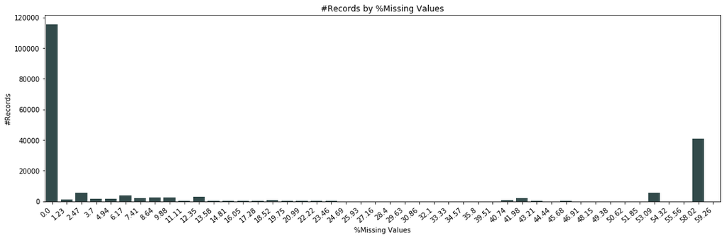

```
Subset 1: #Records 55853
*%Records with >10% Missing values: 29.14 %
Subset 2: #Records 135799
*%Records with <=10% Missing values: 70.86 %
```

|  | CJT_GESAMTTYP_1.0 | CJT_GESAMTTYP_2.0 | CJT_GESAMTTYP_3.0 | CJT_GESAMTTYP_4.0 | CJT_GESAMTTYP_5.0 | CJT_GESAMTTYP_6.0 | FINANZTYP_1 | FINANZTYP_2 | FINANZTYP_3 | FINANZTYP_4 | ... | CAMEO_INTL_wealth_1 | CAMEO_INTL_wealth_2 | CAMEO_INTL_wealth_3 | CAMEO_INTL_wealth_4 | CAMEO_INTL_wealth_5 | CAMEO_INTL_lifestage_1 | CAMEO_INTL_lifestage_2 | CAMEO_INTL_lifestage_3 | CAMEO_INTL_lifestage_4 | CAMEO_INTL_lifestage_5 |
| --- | --- | --- | --- | --- | --- | --- | --- | --- | --- | --- | --- | --- | --- | --- | --- | --- | --- | --- | --- | --- | --- |
| 0 | 0 | 0 | 0 | 0 | 1 | 0 | 0 | 1 | 0 | 0 | ... | 1 | 0 | 0 | 0 | 0 | 0 | 0 | 1 | 0 | 0 |
| 2 | 0 | 1 | 0 | 0 | 0 | 0 | 0 | 1 | 0 | 0 | ... | 0 | 0 | 1 | 0 | 0 | 0 | 0 | 0 | 1 | 0 |
| 3 | 0 | 1 | 0 | 0 | 0 | 0 | 0 | 0 | 0 | 0 | ... | 0 | 1 | 0 | 0 | 0 | 0 | 0 | 0 | 1 | 0 |
| 4 | 0 | 0 | 0 | 0 | 0 | 1 | 0 | 1 | 0 | 0 | ... | 0 | 0 | 0 | 1 | 0 | 1 | 0 | 0 | 0 | 0 |
| 5 | 0 | 0 | 0 | 1 | 0 | 0 | 0 | 0 | 0 | 0 | ... | 0 | 0 | 1 | 0 | 0 | 0 | 0 | 0 | 1 | 0 |

5 rows × 193 columns

```
(135799, 193)
```

```python
df_more_cust, customer_subset = clean_data(customer_df,feat_info)
```

```python
feat_customer = customer_subset.columns.tolist()
feat_census = azdias_subset_encoded.columns.tolist()

print('Features missing from customer subset dataframe:', list(set(feat_census)-set(feat_customer)))
```

```
Features missing from customer subset dataframe: ['GEBAEUDETYP_5.0']
```

```python
#drop feature ['GEBAEUDETYP'] from azdias and customer subset
try:
    azdias_subset_encoded=azdias_subset_encoded.drop(columns=['GEBAEUDETYP_1.0','GEBAEUDETYP_2.0'
                                                              ,'GEBAEUDETYP_3.0','GEBAEUDETYP_4.0', 'GEBAEUDETYP_5.0'
                                                              ,'GEBAEUDETYP_6.0', 'GEBAEUDETYP_8.0']
                                                              ,axis=1)
    customer_subset=customer_subset.drop(columns=['GEBAEUDETYP_1.0','GEBAEUDETYP_2.0'
                                                              ,'GEBAEUDETYP_3.0','GEBAEUDETYP_4.0'
                                                              ,'GEBAEUDETYP_6.0', 'GEBAEUDETYP_8.0']
                                                              ,axis=1)
except:
    pass
print(customer_subset.shape)
print(azdias_subset_encoded.shape)
```

```
(135799, 187)
(771701, 187)
```

```python
feat_customer = customer_subset.columns.tolist()
feat_census = azdias_subset_encoded.columns.tolist()
feat_customer==feat_census
```

```
True
```

### Summary 1.3: Clean up Customer Data

> Follow exact same steps of cleaning Population Dataset to clean Customer dataset. After cleaning, as there is 1 feature value missing from Customer Data which is ['GEBAEUDETYP_5.0'], and to ensure the 2 dataset aligned. I decided to drop the multilevel feature: [GEBAEUDETYP] from both dataset.

> After this step, only **187** features are retained for both datasets. The order of features in both dataset are also the same.

## Step 2: Feature Transformation

To prepare data for Clustering analysis, the features need to be transformed so that the differences in the scale of data don't create any artificial clusters. Besides, after one-hot encoding, the number of features have increased from 85 to 187 features. Increasing number of features also cause the curse of dimensionality where large number of features creates noises and difficulties for Machine to learn and generalize:

> > *'Hughes Phenomenon shows that as the number of features increases, the classifier’s performance increases as well until we reach the optimal number of features. Adding more features based on the same size as the training set will then degrade the classifier’s performance.'* (source: [Curse of Dimensionality](https://towardsdatascience.com/curse-of-dimensionality-2092410f3d27))

To tackle the curse of dimensionality, we can perform Principle component analysis (PCA) with find components that maximize the variance in the data while efficiently compressing the data

This step have 2 substeps:

- 2.1. Impute missing values with most frequent data occurences, then apply feature scaling on the numeric and ordinal data using Standard Scaler to make sure data are scaled with mean 0 and standard deviation =1.
- 2.2. Perform Principal Component Analysis (PCA) for dimensionality reduction while maintaining the variance in data

### Step 2.1: Impute missing data and Apply Feature Scaling

```python
start=time.time()
imp_frequent = Imputer(missing_values = np.nan, strategy='most_frequent',axis=1)
imp_frequent.fit(azdias_subset_encoded)
imputed_azdias_subset =pd.DataFrame(imp_frequent.transform(azdias_subset_encoded),
                                    columns=azdias_subset_encoded.columns)

print(time.time()-start)
```

```python
feat_to_scale = list(num_feat+ord_feat)
feat_to_scale.append('PRAEGENDE_JUGENDJAHRE_decade')
```

```python
azdias_subset_encoded[feat_to_scale].describe()
```

|  | ANZ_PERSONEN | ANZ_TITEL | ANZ_HAUSHALTE_AKTIV | ANZ_HH_TITEL | MIN_GEBAEUDEJAHR | KBA13_ANZAHL_PKW | ALTERSKATEGORIE_GROB | FINANZ_MINIMALIST | FINANZ_SPARER | FINANZ_VORSORGER | ... | PLZ8_ANTG1 | PLZ8_ANTG2 | PLZ8_ANTG3 | PLZ8_ANTG4 | PLZ8_HHZ | PLZ8_GBZ | ARBEIT | ORTSGR_KLS9 | RELAT_AB | PRAEGENDE_JUGENDJAHRE_decade |
| --- | --- | --- | --- | --- | --- | --- | --- | --- | --- | --- | --- | --- | --- | --- | --- | --- | --- | --- | --- | --- | --- |
| count | 771701.000000 | 771701.000000 | 766297.000000 | 768680.000000 | 771701.000000 | 766668.000000 | 769218.000000 | 771701.000000 | 771701.000000 | 771701.000000 | ... | 764477.000000 | 764477.000000 | 764477.000000 | 764477.000000 | 764477.000000 | 764477.000000 | 767846.000000 | 767929.000000 | 767846.000000 | 747372.000000 |
| mean | 1.736555 | 0.004131 | 8.445025 | 0.041026 | 1992.971236 | 618.633738 | 2.795899 | 3.049546 | 2.712087 | 3.437799 | ... | 2.251650 | 2.803621 | 1.597857 | 0.700642 | 3.613121 | 3.379088 | 3.174775 | 5.309178 | 3.080062 | 73.243726 |
| std | 1.158083 | 0.068176 | 15.742858 | 0.326032 | 2.494350 | 339.131287 | 1.019685 | 1.377382 | 1.485991 | 1.377294 | ... | 0.972444 | 0.920308 | 0.986728 | 0.727518 | 0.973171 | 1.111703 | 0.996813 | 2.302183 | 1.358996 | 14.580128 |
| min | 0.000000 | 0.000000 | 1.000000 | 0.000000 | 1985.000000 | 0.000000 | 1.000000 | 1.000000 | 1.000000 | 1.000000 | ... | 0.000000 | 0.000000 | 0.000000 | 0.000000 | 1.000000 | 1.000000 | 1.000000 | 1.000000 | 1.000000 | 40.000000 |
| 25% | 1.000000 | 0.000000 | 2.000000 | 0.000000 | 1992.000000 | 383.000000 | 2.000000 | 2.000000 | 1.000000 | 2.000000 | ... | 1.000000 | 2.000000 | 1.000000 | 0.000000 | 3.000000 | 3.000000 | 3.000000 | 4.000000 | 2.000000 | 60.000000 |
| 50% | 1.000000 | 0.000000 | 4.000000 | 0.000000 | 1992.000000 | 548.000000 | 3.000000 | 3.000000 | 3.000000 | 4.000000 | ... | 2.000000 | 3.000000 | 2.000000 | 1.000000 | 4.000000 | 3.000000 | 3.000000 | 5.000000 | 3.000000 | 70.000000 |
| 75% | 2.000000 | 0.000000 | 10.000000 | 0.000000 | 1993.000000 | 776.000000 | 4.000000 | 4.000000 | 4.000000 | 5.000000 | ... | 3.000000 | 3.000000 | 2.000000 | 1.000000 | 4.000000 | 4.000000 | 4.000000 | 7.000000 | 4.000000 | 90.000000 |
| max | 45.000000 | 4.000000 | 595.000000 | 23.000000 | 2010.000000 | 2300.000000 | 4.000000 | 5.000000 | 5.000000 | 5.000000 | ... | 4.000000 | 4.000000 | 3.000000 | 2.000000 | 5.000000 | 5.000000 | 5.000000 | 9.000000 | 5.000000 | 90.000000 |

8 rows × 56 columns

```python
scaler = StandardScaler()
scaler.fit(imputed_azdias_subset[feat_to_scale])
```

```
StandardScaler(copy=True, with_mean=True, with_std=True)
```

```python
# Apply feature scaling to the general population demographics data.
#imputed_azdias_subset.head()

imputed_azdias_subset[feat_to_scale] = pd.DataFrame(scaler.transform(imputed_azdias_subset[feat_to_scale]),
                                     columns = feat_to_scale)
```

```python
imputed_azdias_subset[feat_to_scale].describe()
```

|  | ANZ_PERSONEN | ANZ_TITEL | ANZ_HAUSHALTE_AKTIV | ANZ_HH_TITEL | MIN_GEBAEUDEJAHR | KBA13_ANZAHL_PKW | ALTERSKATEGORIE_GROB | FINANZ_MINIMALIST | FINANZ_SPARER | FINANZ_VORSORGER | ... | PLZ8_ANTG1 | PLZ8_ANTG2 | PLZ8_ANTG3 | PLZ8_ANTG4 | PLZ8_HHZ | PLZ8_GBZ | ARBEIT | ORTSGR_KLS9 | RELAT_AB | PRAEGENDE_JUGENDJAHRE_decade |
| --- | --- | --- | --- | --- | --- | --- | --- | --- | --- | --- | --- | --- | --- | --- | --- | --- | --- | --- | --- | --- | --- |
| count | 7.717010e+05 | 7.717010e+05 | 7.717010e+05 | 7.717010e+05 | 7.717010e+05 | 7.717010e+05 | 7.717010e+05 | 7.717010e+05 | 7.717010e+05 | 7.717010e+05 | ... | 7.717010e+05 | 7.717010e+05 | 7.717010e+05 | 7.717010e+05 | 7.717010e+05 | 7.717010e+05 | 7.717010e+05 | 7.717010e+05 | 7.717010e+05 | 7.717010e+05 |
| mean | 4.462869e-17 | -1.463991e-18 | -4.761652e-17 | -3.026501e-17 | -1.891107e-14 | -7.623800e-18 | 1.355250e-16 | 2.016440e-18 | 2.053270e-18 | -6.504169e-17 | ... | 4.600061e-17 | 2.643424e-16 | -5.582500e-17 | -5.659843e-17 | 1.045556e-16 | 1.614257e-16 | 1.954842e-16 | -7.327779e-17 | 5.669971e-17 | 3.679266e-16 |
| std | 1.000001e+00 | 1.000001e+00 | 1.000001e+00 | 1.000001e+00 | 1.000001e+00 | 1.000001e+00 | 1.000001e+00 | 1.000001e+00 | 1.000001e+00 | 1.000001e+00 | ... | 1.000001e+00 | 1.000001e+00 | 1.000001e+00 | 1.000001e+00 | 1.000001e+00 | 1.000001e+00 | 1.000001e+00 | 1.000001e+00 | 1.000001e+00 | 1.000001e+00 |
| min | -1.499509e+00 | -6.059522e-02 | -5.340163e-01 | -1.255844e-01 | -3.195718e+00 | -1.798800e+00 | -2.704991e+00 | -1.488002e+00 | -1.152152e+00 | -1.769993e+00 | ... | -2.248852e+00 | -2.908401e+00 | -1.592327e+00 | -9.544070e-01 | -3.477739e+00 | -2.902395e+00 | -3.099403e+00 | -2.271177e+00 | -2.232299e+00 | -3.689340e+00 |
| 25% | -6.360124e-01 | -6.059522e-02 | -4.066556e-01 | -1.255844e-01 | -3.893747e-01 | -6.866213e-01 | -7.637746e-01 | -7.619870e-01 | -1.152152e+00 | -1.043931e+00 | ... | -1.240657e+00 | -8.140494e-01 | -5.863711e-01 | -9.544070e-01 | -5.628611e-01 | -3.012599e-01 | -1.559213e-01 | -5.516396e-01 | -7.755060e-01 | -5.687138e-01 |
| 50% | -6.360124e-01 | -6.059522e-02 | -2.792948e-01 | -1.255844e-01 | -3.893747e-01 | -2.037015e-01 | 2.068335e-01 | -3.597145e-02 | 1.937519e-01 | 4.081926e-01 | ... | -2.324620e-01 | 2.331262e-01 | 4.195849e-01 | 4.206536e-01 | -5.628611e-01 | -3.012599e-01 | -1.559213e-01 | -1.217551e-01 | -4.710928e-02 | -4.860950e-02 |
| 75% | 2.274841e-01 | -6.059522e-02 | 1.027873e-01 | -1.255844e-01 | 1.153156e-02 | 4.665326e-01 | 1.177442e+00 | 6.900441e-01 | 8.667040e-01 | 1.134255e+00 | ... | 7.757330e-01 | 2.331262e-01 | 4.195849e-01 | 4.206536e-01 | 4.087648e-01 | 5.657852e-01 | 8.252394e-01 | 7.380138e-01 | 6.812874e-01 | 9.915991e-01 |
| max | 3.735783e+01 | 5.861117e+01 | 3.735580e+01 | 7.055597e+01 | 6.826938e+00 | 4.932809e+00 | 1.177442e+00 | 1.416060e+00 | 1.539656e+00 | 1.134255e+00 | ... | 1.783928e+00 | 1.280302e+00 | 1.425541e+00 | 1.795714e+00 | 1.380391e+00 | 1.432830e+00 | 1.806400e+00 | 1.597783e+00 | 1.409684e+00 | 9.915991e-01 |

8 rows × 56 columns

```python
X_std = imputed_azdias_subset.values
X_std.shape
```

```
(771701, 187)
```

```python
cov_mat = np.cov(X_std.T)
cov_mat.shape
```

```
(187, 187)
```

### Summary 2.1: Apply Feature Scaling

> Feature Scaling is especially important for Principle Component Analysis. As PCA looks to find the components that maximize data variance, PCA might give more weight to unscaled features as they appear to provide more variance given their unbalanced scale, and it's clearly not correct. -> Reference [Importance of feature scaling](https://scikit-learn.org/stable/auto_examples/preprocessing/plot_scaling_importance.html)

### Step 2.2: Perform Dimensionality Reduction

Apply Principle Component Analysis on scaled features -> Decide the best number of PCAs with the good threshold of variance explained

```python
# Apply PCA to the data.
import time
start=time.time()
from sklearn.decomposition import PCA
pca = PCA()
pca.fit(X_std)
Y = pca.transform(X_std)

print(time.time()-start)
```

```
90.04469466209412
```

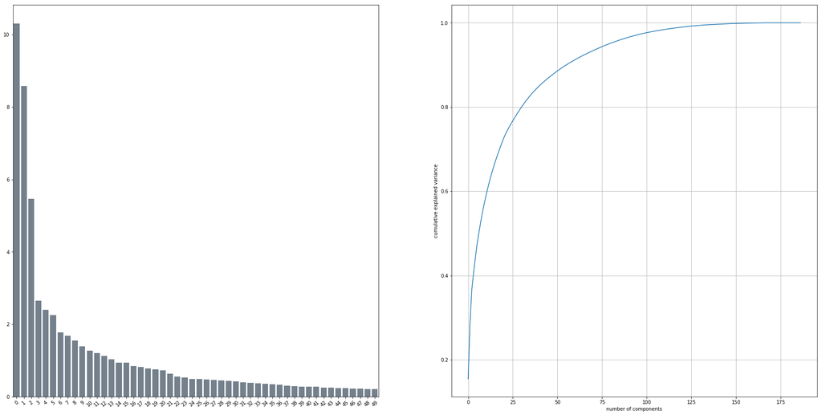

```python
# Investigate the variance accounted for by each principal component.
#plot explained variance amount by number of pcas
plt.figure(figsize=(30,15))
plt.subplot(1,2,1)
ax = sns.barplot(x=np.arange(0,50),y=pca.explained_variance_[:50], color='slategray')
ax.set_xticklabels(ax.get_xticklabels(),rotation=40, fontsize=10);

plt.subplot(1,2,2)
ax= plt.plot(np.cumsum(pca.explained_variance_ratio_));
plt.xlabel('number of components');
plt.ylabel('cumulative explained variance');
plt.grid(True);
plt.show();
```

```python
# Re-apply PCA to the data while selecting for number of components to retain.
start=time.time()
from sklearn.decomposition import PCA
pca_new = PCA(n_components = 25)
pca_new.fit(X_std)
pca_pop = pca_new.transform(X_std)

print(time.time()-start)
```

```
48.0247220993042
```

```python
pca_pop_df = pd.DataFrame(pca_pop, columns = np.arange(0,25))
pca_pop_df.describe()
```

|  | 0 | 1 | 2 | 3 | 4 | 5 | 6 | 7 | 8 | 9 | ... | 15 | 16 | 17 | 18 | 19 | 20 | 21 | 22 | 23 | 24 |
| --- | --- | --- | --- | --- | --- | --- | --- | --- | --- | --- | --- | --- | --- | --- | --- | --- | --- | --- | --- | --- | --- |
| count | 7.717010e+05 | 7.717010e+05 | 7.717010e+05 | 7.717010e+05 | 7.717010e+05 | 7.717010e+05 | 7.717010e+05 | 7.717010e+05 | 7.717010e+05 | 7.717010e+05 | ... | 7.717010e+05 | 7.717010e+05 | 7.717010e+05 | 7.717010e+05 | 7.717010e+05 | 7.717010e+05 | 7.717010e+05 | 7.717010e+05 | 7.717010e+05 | 7.717010e+05 |
| mean | -2.833696e-16 | 1.533047e-17 | 1.412889e-16 | 3.078984e-17 | -5.491346e-17 | 1.174139e-16 | -8.655038e-19 | -2.701477e-17 | -3.196840e-17 | -2.539425e-17 | ... | 1.351659e-17 | -5.960927e-17 | -6.319099e-17 | 8.664246e-18 | 7.576842e-17 | -3.561456e-17 | 2.110356e-17 | -3.850111e-17 | 7.336066e-17 | -2.312000e-17 |
| std | 3.209728e+00 | 2.929937e+00 | 2.336128e+00 | 1.629688e+00 | 1.549072e+00 | 1.500430e+00 | 1.332478e+00 | 1.296014e+00 | 1.246744e+00 | 1.178586e+00 | ... | 9.687219e-01 | 9.166566e-01 | 9.023328e-01 | 8.815499e-01 | 8.715274e-01 | 8.491602e-01 | 7.968899e-01 | 7.404263e-01 | 7.251106e-01 | 6.990790e-01 |
| min | -7.846934e+00 | -7.933190e+00 | -5.229171e+00 | -6.191963e+00 | -6.955962e+00 | -4.492373e+00 | -5.139892e+00 | -4.812268e+00 | -1.144962e+01 | -6.070940e+00 | ... | -1.234900e+01 | -7.435005e+00 | -2.190777e+01 | -5.604816e+00 | -2.196205e+01 | -3.627306e+00 | -3.842111e+00 | -3.432492e+00 | -4.185825e+00 | -5.334549e+00 |
| 25% | -2.640625e+00 | -2.197148e+00 | -2.081774e+00 | -1.107313e+00 | -1.068435e+00 | -1.072376e+00 | -9.126612e-01 | -8.547748e-01 | -8.760802e-01 | -7.161802e-01 | ... | -5.717430e-01 | -5.705143e-01 | -5.081850e-01 | -5.839345e-01 | -4.860631e-01 | -5.742390e-01 | -5.263638e-01 | -4.969099e-01 | -4.796001e-01 | -4.621973e-01 |
| 50% | -1.545257e-01 | 3.742432e-02 | -4.492953e-01 | -3.919196e-02 | -1.120515e-01 | -1.920994e-01 | -2.382461e-02 | -5.260736e-02 | -1.053721e-01 | -1.399271e-02 | ... | 9.654997e-02 | 4.226082e-02 | 1.722111e-02 | 2.219000e-02 | -2.303605e-03 | -2.313438e-02 | 2.609705e-02 | 1.136341e-02 | 1.188463e-02 | -4.968185e-03 |
| 75% | 2.508783e+00 | 2.149004e+00 | 2.200418e+00 | 1.061872e+00 | 9.736221e-01 | 8.519953e-01 | 8.929174e-01 | 7.618982e-01 | 7.596251e-01 | 6.982603e-01 | ... | 6.620653e-01 | 6.189475e-01 | 5.269460e-01 | 6.059233e-01 | 4.807876e-01 | 5.534829e-01 | 5.411355e-01 | 5.033362e-01 | 4.928786e-01 | 4.580652e-01 |
| max | 1.171424e+01 | 1.108309e+01 | 6.257519e+00 | 7.473115e+00 | 9.515698e+00 | 1.816282e+01 | 2.084116e+01 | 1.180591e+01 | 1.686413e+01 | 2.005281e+01 | ... | 1.375963e+01 | 7.582073e+00 | 2.559772e+01 | 6.706390e+00 | 2.961279e+01 | 4.513909e+00 | 1.424154e+01 | 5.637280e+00 | 4.302050e+00 | 6.882070e+00 |

8 rows × 25 columns

### Summary 2.2: Perform Dimensionality Reduction

> Scree plot shows that 25 pcas help explain ~80% of variability in the dataset, 25 pcas will be kept for subsequent analysis. Besides, after the 25th pca, there's no big improvement in the amount of variance explained

### Step 2.3: Interpret Principal Components

Each principal component is a unit vector that points in the direction of highest variance (after accounting for the variance captured by earlier principal components). The further a weight is from zero, the more the principal component is in the direction of the corresponding feature. If two features have large weights of the same sign (both positive or both negative), then increases in one tend expect to be associated with increases in the other. To contrast, features with different signs can be expected to show a negative correlation: increases in one variable should result in a decrease in the other.

```python
# Map weights for the first principal component to corresponding feature names
# and then print the linked values, sorted by weight.

pca_feature_df = pd.DataFrame(pca_new.components_,
                              columns=imputed_azdias_subset.columns,index=['pca'+str(i) for i in range(25)])
pca_feature_df.head()
```

```python
def print_feature(row_label,pca_feature_df):
    pca_feature = pca_feature_df.sort_values(by=row_label,axis=1,ascending=False).loc[row_label,:]
    top_10=pca_feature[0:10]
    bottom_10 = pca_feature[-10:]
    #print('Top/bottom 10 linked features:\n',top_10, bottom_10)
    #with sns.color_palette("Blues_d",10):
    plt.figure(figsize=(20,8))
    plt.subplot(1,2,1)
    ax = sns.barplot(x=top_10.index,y=top_10.values, color='slategray')
    ax.set_xticklabels(ax.get_xticklabels(), rotation=40, ha="right",fontsize = 10)
    plt.title('top 10 features')
    plt.subplot(1,2,2)
    ax = sns.barplot(x=bottom_10.index,y=bottom_10.values, color = 'brown')
    ax.set_xticklabels(ax.get_xticklabels(), rotation=40, ha="right",fontsize = 10)
    plt.title('bottom 10 features')

    #print(top_10)
    #print(bottom_10)
```

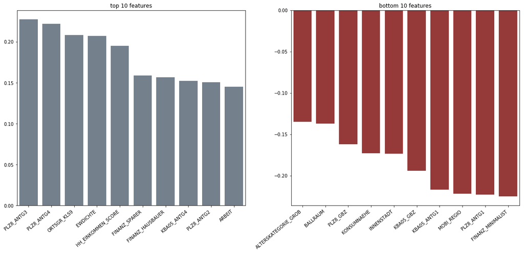

```python
# Map weights for the second principal component to corresponding feature names
# and then print the linked values, sorted by weight.
print_feature('pca0',pca_feature_df)
```

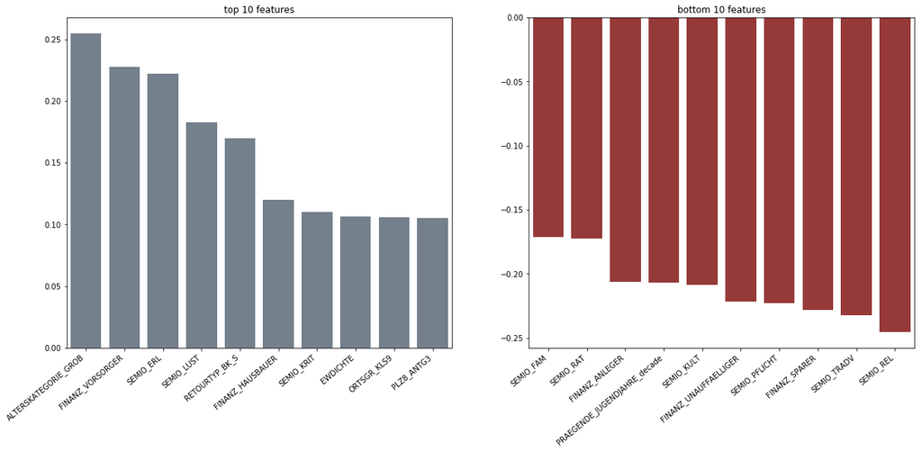

```python
# Map weights for the second principal component to corresponding feature names
# and then print the linked values, sorted by weight.

print_feature('pca1',pca_feature_df)
```

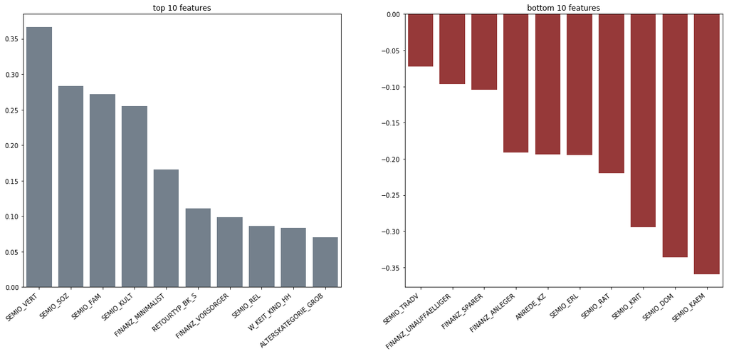

```python
# Map weights for the third principal component to corresponding feature names
# and then print the linked values, sorted by weight.

print_feature('pca2',pca_feature_df)
```

### Summary 2.3: Interpret Principal Components

> - Principle Component 0: captures size of households, size of community and size of the micro-cell, as well as financial situation. MORE **POSITIVE** with highly-dense community, live closer to city center and high movement; MORE **NEGATIVE** with larger distance to city center, less movement tendency and high financial interest
>   > - Number of households in the region with Zip code 8 and size of community (*PLZ8_ANTG3,PLZ8_ANTG4,PLZ8_ANTG1, ORTSGR_KLS9, EWDICHTE*): the more households in the region (6->10 households),the more positive effect. On the other hand, PLZ8_ANTG1 (only 1-2 households) have more negative effect. On the same note, the bigger the community, the more density of households on the same square meters (*EWDICHTE*) the more positive effect. The number of houses and buildings in the microcell also has effect (reflecting in *KBA05_ANTG4, KBA05_ANTG2*). The more houses, the more positive effect, but the more buildings the more negative effect (*PLZ8_GBZ, KBA05_GBZ*)
>   > - Also, the bigger distance between to the city center *INNENSTADT* as well as the less movement tendency *MOBI_REGIO*, the more negative impact on PC0
>   > - Finacial situation of household and individual (*FINANZ_HAUSBAUER,FINANZ_SPARER, FINANZ_MINIMALIST*): people who are LESS likely to be home owners, LESS likely to be money savers have more positive impact, while people with high financial interest have more negative impact
> - Principle Component 1: captures age, personality typology and financial situation.
>   > - Older people who are NOT financially-prepared, NOT event and sensual-oriented have positive effect;
>   > - While Younge who are LESS traditional or religious, and low money-saving affinity have more negative impact
> - Principle Component 2: captures mostly gender (*ANREDE_KZ*), personality topology (*SEMIO*), and return tendency (*RETOURTYP_BK_S*)
>   > - Males who are NOT dreamful, NOT (socially-minded or family-minded or cultural-minded) have positive weight.
>   > - While, Females with less combative attitude, less dominance, less critical minded and less rational have negative weight.

## Step 3: Clustering

### Step 3.1: Apply Clustering to General Population

Apply k-means clustering on General Population dataset in 25 PCA feature space

```python
K = range(1,15)
```

```python
# Over a number of different cluster counts...
# run k-means clustering on the data and...
# compute the average within-cluster distances and the cluster score
start = time.time()
ssd = []
score = []
for k in K:
    kmeans = KMeans(n_clusters=k, random_state=0)
    kmeans = kmeans.fit(pca_pop)
    ssd.append(kmeans.inertia_)
    score.append(kmeans.score(pca_pop))
print((time.time()-start)/60,' minutes')
```

```
24.353359309832253  minutes
```

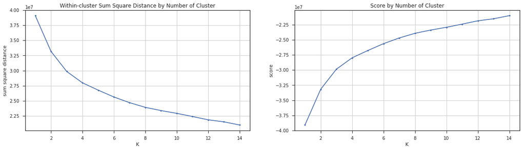

```python
# Investigate the change in within-cluster distance across number of clusters.
# HINT: Use matplotlib's plot function to visualize this relationship.
plt.figure(figsize=(20,5))

plt.subplot(1,2,1)
ax = plt.plot(K,ssd,marker='.')
ax = plt.xlabel('K')
ax = plt.ylabel('sum square distance')
ax = plt.title('Within-cluster Sum Square Distance by Number of Cluster')
plt.grid()

plt.subplot(1,2,2)
ax = plt.plot(K,score,marker='.')
ax = plt.xlabel('K')
ax = plt.ylabel('score')
ax = plt.title('Score by Number of Cluster')
plt.grid()
```

```python
# Re-fit the k-means model with the selected number of clusters and obtain
# cluster predictions for the general population demographics data.

kmeans = KMeans(n_clusters=8, random_state=0)
k_means = kmeans.fit(pca_pop)
```

```python
cluster_pop =kmeans.predict(pca_pop)
centers = k_means.cluster_centers_
pca_pop_df['cluster'] = cluster_pop
pca_pop_df.shape
```

```
(771701, 26)
```

```python
pca_pop_df.describe()
```

|  | 0 | 1 | 2 | 3 | 4 | 5 | 6 | 7 | 8 | 9 | ... | 16 | 17 | 18 | 19 | 20 | 21 | 22 | 23 | 24 | cluster |
| --- | --- | --- | --- | --- | --- | --- | --- | --- | --- | --- | --- | --- | --- | --- | --- | --- | --- | --- | --- | --- | --- |
| count | 7.717010e+05 | 7.717010e+05 | 7.717010e+05 | 7.717010e+05 | 7.717010e+05 | 7.717010e+05 | 7.717010e+05 | 7.717010e+05 | 7.717010e+05 | 7.717010e+05 | ... | 7.717010e+05 | 7.717010e+05 | 7.717010e+05 | 7.717010e+05 | 7.717010e+05 | 7.717010e+05 | 7.717010e+05 | 7.717010e+05 | 7.717010e+05 | 771701.000000 |
| mean | -2.833696e-16 | 1.533047e-17 | 1.412889e-16 | 3.078984e-17 | -5.491346e-17 | 1.174139e-16 | -8.655038e-19 | -2.701477e-17 | -3.196840e-17 | -2.539425e-17 | ... | -5.960927e-17 | -6.319099e-17 | 8.664246e-18 | 7.576842e-17 | -3.561456e-17 | 2.110356e-17 | -3.850111e-17 | 7.336066e-17 | -2.312000e-17 | 3.281070 |
| std | 3.209728e+00 | 2.929937e+00 | 2.336128e+00 | 1.629688e+00 | 1.549072e+00 | 1.500430e+00 | 1.332478e+00 | 1.296014e+00 | 1.246744e+00 | 1.178586e+00 | ... | 9.166566e-01 | 9.023328e-01 | 8.815499e-01 | 8.715274e-01 | 8.491602e-01 | 7.968899e-01 | 7.404263e-01 | 7.251106e-01 | 6.990790e-01 | 2.294993 |
| min | -7.846934e+00 | -7.933190e+00 | -5.229171e+00 | -6.191963e+00 | -6.955962e+00 | -4.492373e+00 | -5.139892e+00 | -4.812268e+00 | -1.144962e+01 | -6.070940e+00 | ... | -7.435005e+00 | -2.190777e+01 | -5.604816e+00 | -2.196205e+01 | -3.627306e+00 | -3.842111e+00 | -3.432492e+00 | -4.185825e+00 | -5.334549e+00 | 0.000000 |
| 25% | -2.640625e+00 | -2.197148e+00 | -2.081774e+00 | -1.107313e+00 | -1.068435e+00 | -1.072376e+00 | -9.126612e-01 | -8.547748e-01 | -8.760802e-01 | -7.161802e-01 | ... | -5.705143e-01 | -5.081850e-01 | -5.839345e-01 | -4.860631e-01 | -5.742390e-01 | -5.263638e-01 | -4.969099e-01 | -4.796001e-01 | -4.621973e-01 | 1.000000 |
| 50% | -1.545257e-01 | 3.742432e-02 | -4.492953e-01 | -3.919196e-02 | -1.120515e-01 | -1.920994e-01 | -2.382461e-02 | -5.260736e-02 | -1.053721e-01 | -1.399271e-02 | ... | 4.226082e-02 | 1.722111e-02 | 2.219000e-02 | -2.303605e-03 | -2.313438e-02 | 2.609705e-02 | 1.136341e-02 | 1.188463e-02 | -4.968185e-03 | 3.000000 |
| 75% | 2.508783e+00 | 2.149004e+00 | 2.200418e+00 | 1.061872e+00 | 9.736221e-01 | 8.519953e-01 | 8.929174e-01 | 7.618982e-01 | 7.596251e-01 | 6.982603e-01 | ... | 6.189475e-01 | 5.269460e-01 | 6.059233e-01 | 4.807876e-01 | 5.534829e-01 | 5.411355e-01 | 5.033362e-01 | 4.928786e-01 | 4.580652e-01 | 5.000000 |
| max | 1.171424e+01 | 1.108309e+01 | 6.257519e+00 | 7.473115e+00 | 9.515698e+00 | 1.816282e+01 | 2.084116e+01 | 1.180591e+01 | 1.686413e+01 | 2.005281e+01 | ... | 7.582073e+00 | 2.559772e+01 | 6.706390e+00 | 2.961279e+01 | 4.513909e+00 | 1.424154e+01 | 5.637280e+00 | 4.302050e+00 | 6.882070e+00 | 7.000000 |

8 rows × 26 columns

```
110.30463457107544
```

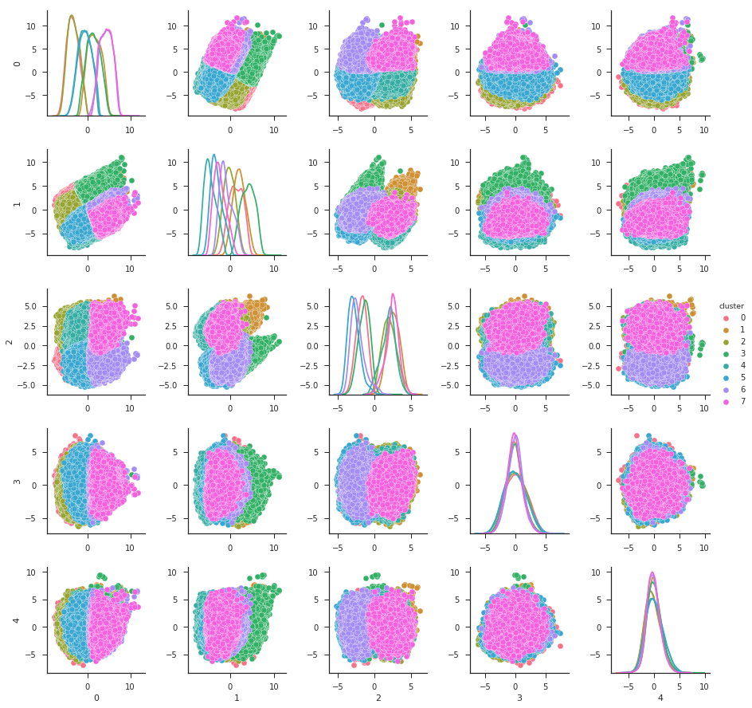

```python
start = time.time()
sns.set(style="ticks", color_codes=True)
g = sns.pairplot(pca_pop_df, vars=[0,1,2,3,4],hue='cluster',diag_kind='kde',palette="husl")
print(time.time()-start)
```

```python
pca0=np.array(pca_pop_df[0])
pca1=np.array(pca_pop_df[1])
pca2=np.array(pca_pop_df[2])
```

```
3.5663821697235107
```

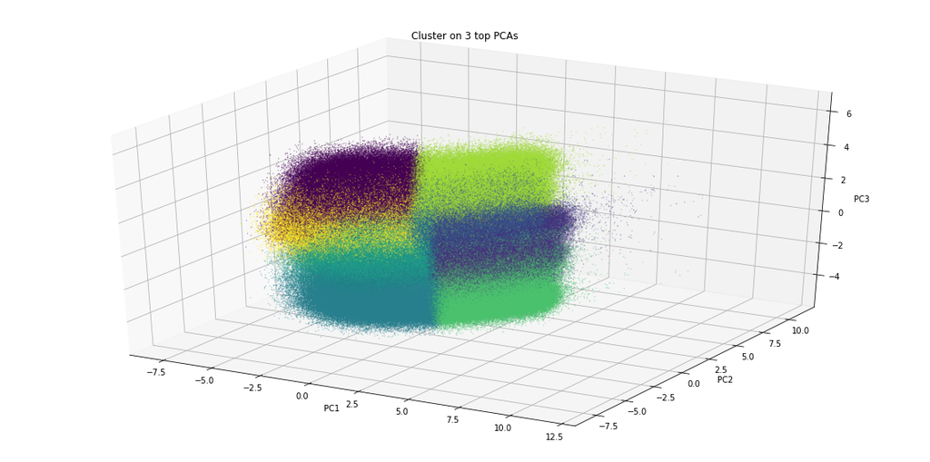

```python
start = time.time()
fig = plt.figure(figsize = (20,10))
ax = plt.axes(projection='3d')
ax.scatter3D(pca0, pca1, pca2,c=pca_pop_df['cluster'],s=0.1);
ax.set_xlabel("PC1");
ax.set_ylabel("PC2");
ax.set_zlabel("PC3");
ax.set_title("Cluster on 3 top PCAs")

print(time.time()-start)
```

### Summary 3.1: Apply Clustering to General Population

> Based on the plot of **elbow test** of **K value** on **"Sum of squared distances (SSD) of samples to their closest cluster center"**, we can see that the SSD decreases more slowly starting from cluster 7 or 8.

> A pairplot between top 5 PCAs pairs and histogram of clusters on each PCA indicates that top 3 PCAs show the clearest separation of clusters. A 3D plot of clusters based on 3 top PCAs confirms this observation.

### Step 3.2: Apply All Steps to the Customer Data

Apply the same feature transformation, feature scaling, PCA and k-means clustering instance on the customer subset. To ensure the consistency of mapping of Customer subset to the population dataset, the instance of all Imputer, StandardScaler, PCA and K-means will be reused after fitting to Population subset. That means, these instance will not be refitted to Customer subset, the *transform* method will be used instead

```python
#Customer subset was cleaned up during Step 1.3
customer_subset.shape
```

```
(135799, 187)
```

```python
# Apply preprocessing, feature transformation, and clustering from the general
# demographics onto the customer data, obtaining cluster predictions for the
# customer demographics data.

#Imputing missing values customer subset
start=time.time()
imputed_customer_subset =pd.DataFrame(imp_frequent.transform(customer_subset),
                                    columns=customer_subset.columns)

print(time.time()-start)

imputed_customer_subset.isna().sum().sum()
```

```
31.588542938232422
```

```
0
```

```python
imputed_azdias_subset[feat_to_scale].describe()
```

|  | ANZ_PERSONEN | ANZ_TITEL | ANZ_HAUSHALTE_AKTIV | ANZ_HH_TITEL | MIN_GEBAEUDEJAHR | KBA13_ANZAHL_PKW | ALTERSKATEGORIE_GROB | FINANZ_MINIMALIST | FINANZ_SPARER | FINANZ_VORSORGER | ... | PLZ8_ANTG1 | PLZ8_ANTG2 | PLZ8_ANTG3 | PLZ8_ANTG4 | PLZ8_HHZ | PLZ8_GBZ | ARBEIT | ORTSGR_KLS9 | RELAT_AB | PRAEGENDE_JUGENDJAHRE_decade |
| --- | --- | --- | --- | --- | --- | --- | --- | --- | --- | --- | --- | --- | --- | --- | --- | --- | --- | --- | --- | --- | --- |
| count | 7.717010e+05 | 7.717010e+05 | 7.717010e+05 | 7.717010e+05 | 7.717010e+05 | 7.717010e+05 | 7.717010e+05 | 7.717010e+05 | 7.717010e+05 | 7.717010e+05 | ... | 7.717010e+05 | 7.717010e+05 | 7.717010e+05 | 7.717010e+05 | 7.717010e+05 | 7.717010e+05 | 7.717010e+05 | 7.717010e+05 | 7.717010e+05 | 7.717010e+05 |
| mean | 4.462869e-17 | -1.463991e-18 | -4.761652e-17 | -3.026501e-17 | -1.891107e-14 | -7.623800e-18 | 1.355250e-16 | 2.016440e-18 | 2.053270e-18 | -6.504169e-17 | ... | 4.600061e-17 | 2.643424e-16 | -5.582500e-17 | -5.659843e-17 | 1.045556e-16 | 1.614257e-16 | 1.954842e-16 | -7.327779e-17 | 5.669971e-17 | 3.679266e-16 |
| std | 1.000001e+00 | 1.000001e+00 | 1.000001e+00 | 1.000001e+00 | 1.000001e+00 | 1.000001e+00 | 1.000001e+00 | 1.000001e+00 | 1.000001e+00 | 1.000001e+00 | ... | 1.000001e+00 | 1.000001e+00 | 1.000001e+00 | 1.000001e+00 | 1.000001e+00 | 1.000001e+00 | 1.000001e+00 | 1.000001e+00 | 1.000001e+00 | 1.000001e+00 |
| min | -1.499509e+00 | -6.059522e-02 | -5.340163e-01 | -1.255844e-01 | -3.195718e+00 | -1.798800e+00 | -2.704991e+00 | -1.488002e+00 | -1.152152e+00 | -1.769993e+00 | ... | -2.248852e+00 | -2.908401e+00 | -1.592327e+00 | -9.544070e-01 | -3.477739e+00 | -2.902395e+00 | -3.099403e+00 | -2.271177e+00 | -2.232299e+00 | -3.689340e+00 |
| 25% | -6.360124e-01 | -6.059522e-02 | -4.066556e-01 | -1.255844e-01 | -3.893747e-01 | -6.866213e-01 | -7.637746e-01 | -7.619870e-01 | -1.152152e+00 | -1.043931e+00 | ... | -1.240657e+00 | -8.140494e-01 | -5.863711e-01 | -9.544070e-01 | -5.628611e-01 | -3.012599e-01 | -1.559213e-01 | -5.516396e-01 | -7.755060e-01 | -5.687138e-01 |
| 50% | -6.360124e-01 | -6.059522e-02 | -2.792948e-01 | -1.255844e-01 | -3.893747e-01 | -2.037015e-01 | 2.068335e-01 | -3.597145e-02 | 1.937519e-01 | 4.081926e-01 | ... | -2.324620e-01 | 2.331262e-01 | 4.195849e-01 | 4.206536e-01 | -5.628611e-01 | -3.012599e-01 | -1.559213e-01 | -1.217551e-01 | -4.710928e-02 | -4.860950e-02 |
| 75% | 2.274841e-01 | -6.059522e-02 | 1.027873e-01 | -1.255844e-01 | 1.153156e-02 | 4.665326e-01 | 1.177442e+00 | 6.900441e-01 | 8.667040e-01 | 1.134255e+00 | ... | 7.757330e-01 | 2.331262e-01 | 4.195849e-01 | 4.206536e-01 | 4.087648e-01 | 5.657852e-01 | 8.252394e-01 | 7.380138e-01 | 6.812874e-01 | 9.915991e-01 |
| max | 3.735783e+01 | 5.861117e+01 | 3.735580e+01 | 7.055597e+01 | 6.826938e+00 | 4.932809e+00 | 1.177442e+00 | 1.416060e+00 | 1.539656e+00 | 1.134255e+00 | ... | 1.783928e+00 | 1.280302e+00 | 1.425541e+00 | 1.795714e+00 | 1.380391e+00 | 1.432830e+00 | 1.806400e+00 | 1.597783e+00 | 1.409684e+00 | 9.915991e-01 |

8 rows × 56 columns

```python
print(feat_to_scale)
imputed_customer_subset[feat_to_scale] = pd.DataFrame(scaler.transform(imputed_customer_subset[feat_to_scale]),
                                     columns = feat_to_scale)
```

[output not shown]

```python
imputed_customer_subset[feat_to_scale].describe()
```

|  | ANZ_PERSONEN | ANZ_TITEL | ANZ_HAUSHALTE_AKTIV | ANZ_HH_TITEL | MIN_GEBAEUDEJAHR | KBA13_ANZAHL_PKW | ALTERSKATEGORIE_GROB | FINANZ_MINIMALIST | FINANZ_SPARER | FINANZ_VORSORGER | ... | PLZ8_ANTG1 | PLZ8_ANTG2 | PLZ8_ANTG3 | PLZ8_ANTG4 | PLZ8_HHZ | PLZ8_GBZ | ARBEIT | ORTSGR_KLS9 | RELAT_AB | PRAEGENDE_JUGENDJAHRE_decade |
| --- | --- | --- | --- | --- | --- | --- | --- | --- | --- | --- | --- | --- | --- | --- | --- | --- | --- | --- | --- | --- | --- |
| count | 135799.000000 | 135799.000000 | 135799.000000 | 135799.000000 | 135799.000000 | 135799.000000 | 135799.000000 | 135799.000000 | 135799.000000 | 135799.000000 | ... | 135799.000000 | 135799.000000 | 135799.000000 | 135799.000000 | 135799.000000 | 135799.000000 | 135799.000000 | 135799.000000 | 135799.000000 | 135799.000000 |
| mean | 0.471910 | 0.239354 | -0.218212 | 0.078989 | -0.056880 | 0.147746 | 0.682342 | 0.886888 | -0.868713 | 0.823805 | ... | 0.298121 | -0.064882 | -0.204875 | -0.217813 | 0.034250 | 0.222010 | -0.340537 | -0.081748 | -0.130806 | -0.653452 |
| std | 1.200877 | 2.236174 | 0.918775 | 1.670289 | 0.963089 | 0.999210 | 0.712290 | 0.736795 | 0.553913 | 0.607719 | ... | 0.929114 | 0.902281 | 0.893333 | 0.874722 | 0.940955 | 0.901314 | 1.002383 | 0.935521 | 1.040875 | 0.735829 |
| min | -1.499509 | -0.060595 | -0.534016 | -0.125584 | -3.195718 | -1.798800 | -2.704991 | -1.488002 | -1.152152 | -1.769993 | ... | -2.248852 | -2.908401 | -1.592327 | -0.954407 | -3.477739 | -2.902395 | -3.099403 | -2.271177 | -2.232299 | -3.689340 |
| 25% | -0.636012 | -0.060595 | -0.470336 | -0.125584 | -0.389375 | -0.543209 | 0.206833 | 0.690044 | -1.152152 | 0.408193 | ... | -0.232462 | -0.814049 | -0.586371 | -0.954407 | -0.562861 | -0.301260 | -1.137082 | -0.551640 | -0.775506 | -1.088818 |
| 50% | 0.227484 | -0.060595 | -0.470336 | -0.125584 | -0.389375 | -0.066143 | 1.177442 | 1.416060 | -1.152152 | 1.134255 | ... | 0.775733 | 0.233126 | -0.586371 | -0.954407 | -0.562861 | 0.565785 | -0.155921 | -0.121755 | -0.047109 | -0.568714 |
| 75% | 1.090981 | -0.060595 | -0.279295 | -0.125584 | -0.389375 | 0.621652 | 1.177442 | 1.416060 | -0.479200 | 1.134255 | ... | 0.775733 | 0.233126 | 0.419585 | 0.420654 | 0.408765 | 0.565785 | 0.825239 | 0.738014 | 0.681287 | -0.048610 |
| max | 16.633918 | 73.279107 | 32.770814 | 70.555970 | 6.826938 | 4.932809 | 1.177442 | 1.416060 | 1.539656 | 1.134255 | ... | 1.783928 | 1.280302 | 1.425541 | 1.795714 | 1.380391 | 1.432830 | 1.806400 | 1.597783 | 1.409684 | 0.991599 |

8 rows × 56 columns

```python
#apply PCA on customer subset
X_cust_std = imputed_customer_subset.values
pca_cust = pca_new.transform(X_cust_std)
print(pca_cust.shape)
```

```
(135799, 25)
```

```python
#predict k means on customer data
cluster_cust = k_means.predict(pca_cust)
np.unique(cluster_cust)
```

```
array([0, 1, 2, 3, 4, 5, 6, 7], dtype=int32)
```

```python
pca_cust_df = pd.DataFrame(pca_cust)
pca_cust_df['cluster'] = cluster_cust
pca_cust_df.head()
```

|  | 0 | 1 | 2 | 3 | 4 | 5 | 6 | 7 | 8 | 9 | ... | 16 | 17 | 18 | 19 | 20 | 21 | 22 | 23 | 24 | cluster |
| --- | --- | --- | --- | --- | --- | --- | --- | --- | --- | --- | --- | --- | --- | --- | --- | --- | --- | --- | --- | --- | --- |
| 0 | -5.406551 | 0.696621 | 3.891899 | 1.665125 | 2.843712 | -0.533177 | -0.147605 | 1.256563 | 0.846963 | 1.016957 | ... | 0.059823 | 1.026462 | 0.122785 | -0.574610 | 0.414271 | 0.580795 | 0.125565 | -0.623394 | -1.273690 | 0 |
| 1 | -1.344548 | 4.806590 | -0.805624 | 0.697034 | -1.271166 | -0.702020 | -0.229334 | 0.963383 | -0.511233 | 1.085472 | ... | 0.964300 | 0.257562 | 0.950480 | 0.353661 | -0.904387 | 0.778601 | -0.501250 | -0.750491 | 1.390666 | 1 |
| 2 | -4.530710 | -0.305695 | 2.409820 | -1.695158 | 0.845319 | 0.161707 | 0.803199 | 0.521410 | -0.214499 | 0.050707 | ... | -1.478938 | -0.152675 | -0.313297 | 0.207131 | -0.813981 | -2.273373 | -0.675720 | 0.683863 | 0.999067 | 0 |
| 3 | 1.314451 | -0.669888 | 1.158772 | -0.124151 | -0.716237 | -1.327146 | -0.123657 | -0.835829 | 1.587762 | 0.488059 | ... | 0.905515 | 0.141532 | -0.447594 | -0.179053 | -0.477825 | 1.250345 | -0.072129 | 1.084944 | 0.474567 | 6 |
| 4 | -2.042546 | 1.076531 | 2.479116 | 2.341090 | 1.249125 | -1.725276 | -0.458765 | -1.074367 | -0.565321 | -0.184309 | ... | 1.095100 | -0.149569 | 0.717045 | 0.432222 | -1.580500 | 0.039510 | -1.846813 | -1.200326 | 1.261658 | 0 |

5 rows × 26 columns

```
21.565685510635376
```

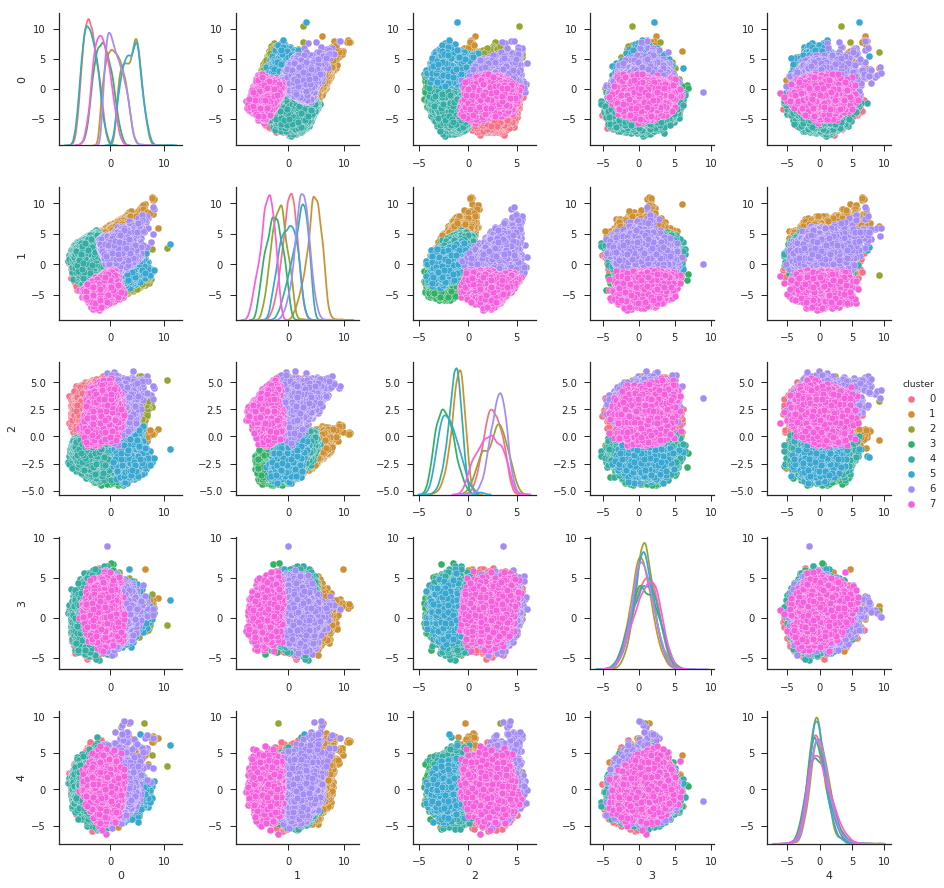

```python
start = time.time()
sns.set(style="ticks", color_codes=True)
g = sns.pairplot(pca_cust_df, vars=[0,1,2,3,4],hue='cluster',diag_kind='kde',palette="husl")
print(time.time()-start)
```

### Step 3.3: Compare Customer Data to Demographics Data

Consider the proportion of persons in each cluster for the general population, and the proportions for the customers. If we think the company's customer base to be universal, then the cluster assignment proportions should be fairly similar between the two. If there are only particular segments of the population that are interested in the company's products, then we should see a mismatch from one to the other. If there is a higher proportion of persons in a cluster for the customer data compared to the general population (e.g. 5% of persons are assigned to a cluster for the general population, but 15% of the customer data is closest to that cluster's centroid) then that suggests the people in that cluster to be a target audience for the company. On the other hand, the proportion of the data in a cluster being larger in the general population than the customer data (e.g. only 2% of customers closest to a population centroid that captures 6% of the data) suggests that group of persons to be outside of the target demographics.

```python
#number of data points dropped from population
dropped_data_pop = df_more.shape[0]
#number of data points dropped from customer data
dropped_data_cust = df_more_cust.shape[0]
print('Number of records dropped from population data:',dropped_data_pop)
print('Number of records dropped from customer data:',dropped_data_cust)
```

```
Number of records dropped from population data: 119520
Number of records dropped from customer data: 55853
```

```python
cluster_label, count_pop = np.unique(cluster_pop,return_counts=True)
cluster_label_cust, count_cust = np.unique(cluster_cust,return_counts=True)
#add the data points dropped in step 1.1.3 back as cluster [-1]
cluster_label = np.append(cluster_label,-1)
count_pop = np.append(count_pop,dropped_data_pop)
cluster_label_cust = np.append(cluster_label_cust,-1)
count_cust = np.append(count_cust,dropped_data_cust)
```

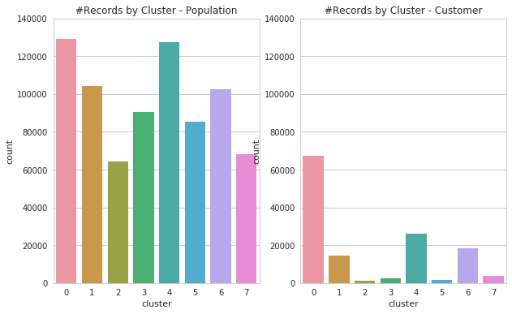

```python
plt.figure(figsize =(10,6))
plt.subplot(1,2,1)
ax = sns.countplot(x='cluster',data=pca_pop_df)
plt.ylim(0,140000);
plt.title('#Records by Cluster - Population')
plt.subplot(1,2,2)
ax = sns.countplot(x='cluster',data=pca_cust_df)
plt.ylim(0,140000);
plt.title('#Records by Cluster - Customer');
```

```python
# Compare the proportion of data in each cluster for the customer data to the
# proportion of data in each cluster for the general population.
count_pop_prop = count_pop/count_pop.sum()*100
count_cust_prop = count_cust/count_cust.sum()*100
diff = count_cust_prop-count_pop_prop
stack_cluster_prop = np.vstack((count_pop, count_cust, count_pop_prop,count_cust_prop, diff))
stack_cluster_prop = np.transpose(stack_cluster_prop)
```

```python
cluster_prop_df = pd.DataFrame(stack_cluster_prop,columns=['Population_count','Customer_count'
                                                           ,'Population_prop','Customer_prop'
                                                           ,'Diff_prop'],index=cluster_label)
display(cluster_prop_df)
```

|  | Population_count | Customer_count | Population_prop | Customer_prop | Diff_prop |
| --- | --- | --- | --- | --- | --- |
| 0 | 129254.0 | 67377.0 | 14.503025 | 35.155908 | 20.652883 |
| 1 | 104313.0 | 14700.0 | 11.704504 | 7.670152 | -4.034352 |
| 2 | 64460.0 | 1336.0 | 7.232774 | 0.697097 | -6.535677 |
| 3 | 90524.0 | 2634.0 | 10.157301 | 1.374366 | -8.782935 |
| 4 | 127207.0 | 25918.0 | 14.273340 | 13.523470 | -0.749870 |
| 5 | 85406.0 | 1544.0 | 9.583033 | 0.805627 | -8.777406 |
| 6 | 102417.0 | 18456.0 | 11.491762 | 9.629954 | -1.861808 |
| 7 | 68120.0 | 3834.0 | 7.643446 | 2.000501 | -5.642946 |
| -1 | 119520.0 | 55853.0 | 13.410815 | 29.142926 | 15.732111 |

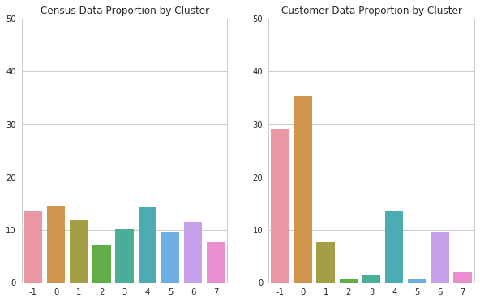

```python
sns.set(style = 'whitegrid')
plt.figure(figsize =(10,6))
plt.subplot(1,2,1)
ax = sns.barplot(cluster_label, count_pop_prop)
plt.ylim(0,50)
plt.title('Census Data Proportion by Cluster')
plt.subplot(1,2,2)
ax = sns.barplot(cluster_label_cust, count_cust_prop)
plt.ylim(0,50)
plt.title('Customer Data Proportion by Cluster');
```

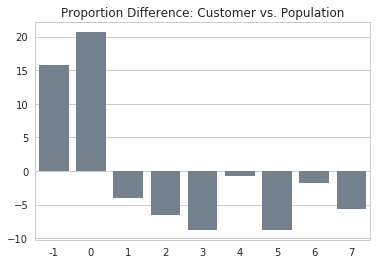

```python
ax = sns.barplot(cluster_label, diff, color='slategray')
plt.title('Proportion Difference: Customer vs. Population');
```

### Summary 3.3: Overrepresented and underrepresented Customer Segment

> Cluster 0 is the cluster which are overrepresenting in the customer data.
> > - Cluster 0 only represents about 15% in population data, but up to 35% in customer data;
> > - Cluster -1 (the cluster with missing data) takes up 29% in customer data, compared to only 13% in population data

```python
def plot_boxplot_3pca(df,df_cluster,title1,title2,c1,c2):

    plt.figure(figsize=(10,10))
    plt.subplot(2,3,1)
    ax = sns.boxplot(y=df[0],color = c1)
    plt.title(title1)
    plt.subplot(2,3,2)
    ax = sns.boxplot(y=df[1],color = c1)
    plt.title(title1)
    plt.subplot(2,3,3)
    ax = sns.boxplot(y=df[2],color = c1)
    plt.title(title1)

    plt.subplot(2,3,4)
    ax = sns.boxplot(y=df_cluster[0],color = c2)
    plt.title(title2)
    plt.subplot(2,3,5)
    ax = sns.boxplot(y=df_cluster[1],color = c2)
    plt.title(title2)
    plt.subplot(2,3,6)
    ax = sns.boxplot(y=df_cluster[2],color = c2)
    plt.title(title2)
```

```
DISTRIBUTION OF 3 MAJOR PCAs between CLUSTER 0 AND CUSTOMER DATA
```

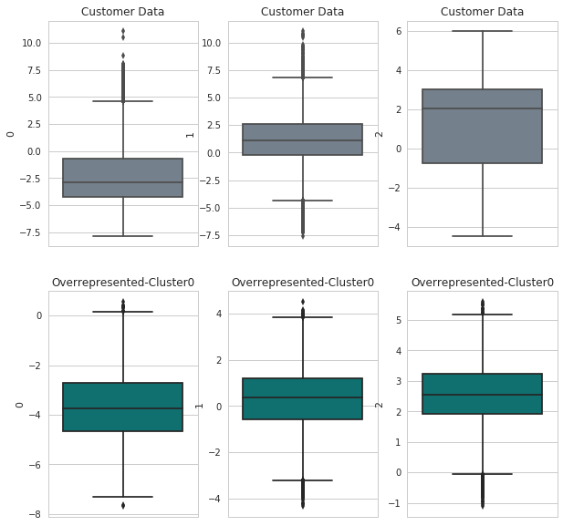

```python
print('DISTRIBUTION OF 3 MAJOR PCAs between CLUSTER 0 AND CUSTOMER DATA')
cluster_0_df = pca_cust_df[pca_cust_df['cluster']==0]
plot_boxplot_3pca(pca_cust_df, cluster_0_df,'Customer Data','Overrepresented-Cluster0','slategray','teal')
```

```
DISTRIBUTION OF 3 MAJOR PCAs between CLUSTER 5 AND CUSTOMER DATA
```

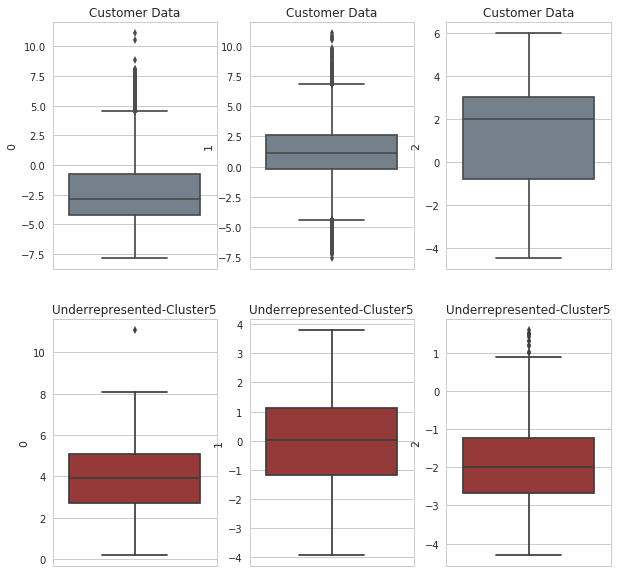

```python
print('DISTRIBUTION OF 3 MAJOR PCAs between CLUSTER 5 AND CUSTOMER DATA')
cluster_5_df = pca_cust_df[pca_cust_df['cluster']==5]
plot_boxplot_3pca(pca_cust_df,cluster_5_df,'Customer Data','Underrepresented-Cluster5','slategray','brown')
```

```
DISTRIBUTION OF 3 MAJOR PCAs between Overrepresented CLUSTER 0 AND Underpresented CLUSTER 5 in CUSTOMER DATA
```

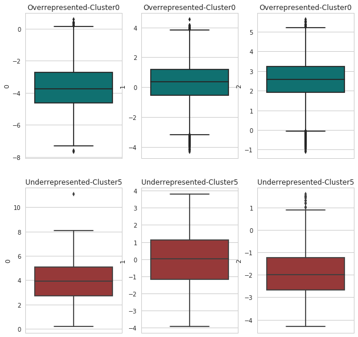

```python
print('DISTRIBUTION OF 3 MAJOR PCAs between Overrepresented CLUSTER 0 AND Underpresented CLUSTER 5 in CUSTOMER DATA')
cluster_5_df = pca_cust_df[pca_cust_df['cluster']==5]
plot_boxplot_3pca(cluster_0_df,cluster_5_df, 'Overrepresented-Cluster0','Underrepresented-Cluster5','teal','brown')
```

### Discussion 3.3: Compare Customer Data to Demographics Data

> Based on the Boxplots of 3 major PCAs, we can see that:
> > - Overrepresented Cluster (Cluster 0) has more negative **PC0** than Overall Customer Subset and Underrepresented Cluster (Cluster 5).
> > - Overrepresented Cluster (Cluster 0) has slightly more positive **PC1** than Underrepresented Cluster (Cluster 5).
> > - Overrepresented Cluster (Cluster 0) has more positive **PC2** than Underrepresented Cluster (Cluster 5).

> Based on discussion in Step 2.3, Segment of the population which is relatively POPULAR to this mail-order company is corresponding to **negative PC0**, **more positive PC1**, **more positive PC2**. This segment tend to comprise of people who live in less dense areas, less travel move, far away from city center and more affluent. They are older people who are less event, sensual and critical minded. They also tend to be Male who are NOT socially-minded, family-minded or socially oriented.

> Segment of the population which is relatively UNPOPULAR to this mail-order company are those in dense community, live closer to the city center. They can also likely be younger people who are not Money-savers, or female are who less rational, critical and dominant.